# STA141A HW1

Kefan Pan 919640852

2025-01-17

Q1. Data science is like cooking, but we do not use vegetables or meats as our ingredients. We use data such as numbers, factors, and information we collected. First, We need our “Hypothesis” which correspond to the decision that what food we will cook tonight. Second, We should make “Experiment” which correspond to the process that make our dinner. Third We will come up with our “Data” which correspond to our dishes. Forth, We need “Analysis” which correspond to eat dinner. Finally, We need “Conclusion” which correspond to our opinions to those dishes.

Q2. My top two strengths of mine that apply to data science: 1. Programming. Before this class, STA141A, I’ve taken STA108, STA106, and ECN 145. These courses deepened my understanding in R. And I’ve developed confidence in coding such as visualization and combining. I’ve gained hands on experience in R. These are really important in complete works in R. 2. Critical thinking. This this my last year in UCDavis. I’ve learned to view a case or problem from different angles in these four years. For example, asking questions to myself about Why this happened? Where did the problem occurred? What should I concluded? It is really important in evaluating data. It can help me to refine my conclusion. 3. My Plan. I will make a good use of my strengths. I will ensure my final project is actionable and insightful. I will try my best to encounter technical tasks.

Q3. i. The task I feel least confident about is Iteration. It means repeat till the condition meet. For example,

```r
x <- 0
for (i in 1:10){
  x <- x + i
}
print (x)
```

```
## [1] 55
```

2. Why I feel least confident about it? Iteration always combined with complex loops or structures with large datasets. And I do not have much experience in doing it.
3. How i plan to improve. First, start with something easier. Just like the example I gave above. Second, If i find something I can’t handle with, I will go to office hour immediatly.

Q4. i.

```r
y <- c(81, 170, 1923, 3825)
y3 <- y %% 3 == 0
y9 <- y %% 9 == 0
print(y3)
```

```
## [1]  TRUE FALSE  TRUE  TRUE
```

```r
print(y9)
```

```
## [1]  TRUE FALSE FALSE  TRUE
```

Conclusion: 81, 1923, 3825 are divisible by 3 . 170 can not 81, 3825 are divisible by 9. 170 and 1923 can not 81, 3825 are divisible by 3 and 9. 170 and 1923 can not

```r
sum <- (y %/% 1000) + ((y %% 1000) %/% 100) + ((y %% 100) %/% 10) + (y %% 10)
print (sum)
```

```
## [1]  9  8 15 18
```

```r
sum3 <- sum %% 3 == 0
sum9 <- sum %% 9 == 0
print(sum3)
```

```
## [1]  TRUE FALSE  TRUE  TRUE
```

```r
print(sum9)
```

```
## [1]  TRUE FALSE FALSE  TRUE
```

4. observation: 81, 1923, 3825 are divisible by 3 . 170 can not 81, 3825 are divisible by 9. 170 and 1923 can not 81, 3825 are divisible by 3 and 9. 170 and 1923 can not The sum of 81 and 3825 are divisible by 3 and 9. The sum of 170 and 1923 can not. If the sum of any number is divisible by 3 and 9, then this number is divisible by 3 and 9. For example: 18

```r
z <- c(18)
sum2 <- (z %/% 10) + (z %% 10)
print (sum2)
```

```
## [1] 9
```

the sum of digit is 9 which is divisible by 3 and 9. So 18 is divisible by 3 and 9

Q5. i.
$$2\cdot \left(\frac{2}{1}\cdot \frac{2}{3}\right) \left(\frac{4}{3}\cdot
\frac{4}{5}\right)\left(\frac{6}{5}\cdot \frac{6}{7}\right)$$

```r
a <- c(2,4,6)
b <- c(1,3,5)
c <- c(3,5,7)
prod <- 2 * prod((a / b) * (a / c))
print(prod)
```

```
## [1] 2.925714
```

2. $$2\cdot \left(\frac{2}{1}\cdot \frac{2}{3}\right) \left(\frac{4}{3}\cdot
   \frac{4}{5}\right)\cdots \left(\frac{1000}{999}\cdot
   \frac{1000}{1001}\right)$$

```r
d <- seq(2,1000,2)
e <- seq(1,999,2)
f <- seq(3,1001,2)
prod2 <- 2*prod((d / e) * (d / f))
print(prod2)
```

```
## [1] 3.140024
```

Q6.
$$2\cdot \left(\frac{2}{1}\cdot \frac{2}{3}\right) \left(\frac{4}{3}\cdot
\frac{4}{5}\right)\cdots \left(\frac{2n}{2n-1}\cdot
\frac{2n}{2n+1}\right)$$

```r
g <- function(n) {
  h <- seq(2, 2 * n, 2)
  2 * prod((h / (h - 1)) * (h / (h + 1)))
}
test <- c(17, 91, 216)

result <- sapply(test, g)

print(result)
```

```
## [1] 3.097038 3.133021 3.137967
```

Q7.

```r
j <- seq(5, 500, by = 5)
k <- sapply(j,g)
print(k)
```

```
##   [1] 3.002176 3.067704 3.091337 3.103517 3.110945 3.115948 3.119547 3.122260
##   [9] 3.124379 3.126079 3.127473 3.128638 3.129625 3.130472 3.131207 3.131851
##  [17] 3.132420 3.132926 3.133379 3.133787 3.134157 3.134493 3.134800 3.135082
##  [25] 3.135341 3.135580 3.135802 3.136008 3.136199 3.136378 3.136546 3.136703
##  [33] 3.136851 3.136990 3.137121 3.137244 3.137362 3.137473 3.137578 3.137678
##  [41] 3.137773 3.137864 3.137950 3.138033 3.138112 3.138187 3.138259 3.138329
##  [49] 3.138395 3.138459 3.138520 3.138579 3.138636 3.138690 3.138743 3.138794
##  [57] 3.138843 3.138890 3.138936 3.138980 3.139023 3.139064 3.139104 3.139143
##  [65] 3.139181 3.139217 3.139253 3.139287 3.139320 3.139353 3.139384 3.139415
##  [73] 3.139445 3.139474 3.139502 3.139529 3.139556 3.139582 3.139607 3.139632
##  [81] 3.139656 3.139680 3.139703 3.139725 3.139747 3.139769 3.139790 3.139810
##  [89] 3.139830 3.139850 3.139869 3.139888 3.139906 3.139924 3.139941 3.139959
##  [97] 3.139975 3.139992 3.140008 3.140024
```

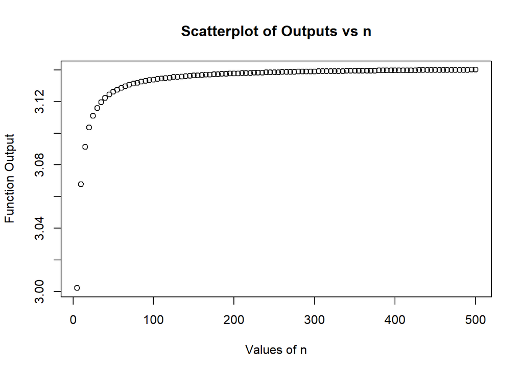

```r
plot(j,k,main = "Scatterplot of Outputs vs n", xlab = "Values of n", ylab = "Function Output")
```

Q8.

```r
library(readr)
```

```r
cars <- read_csv("C:/Users/panke/Desktop/cars.csv")
data(cars)
head(cars)
```

```
##   speed dist
## 1     4    2
## 2     4   10
## 3     7    4
## 4     7   22
## 5     8   16
## 6     9   10
```

```r
nrow(cars)
```

```
## [1] 50
```

```r
ncol(cars)
```

```
## [1] 2
```

```r
?cars
```

```
## 打开httpd帮助服务器… 好了
```

Q9. In dataset “cars”, there’re two columns: speed and dist. They represent speed of the car in miles per hour and the distance of the car in feet. speed means how fast the car drove during the observation. dist means how far the car drove during the observation.

Q10. each row represent the speed and distances of each car that observed. For example,one car speed is 11mph and distance is 28ft.

Q11.

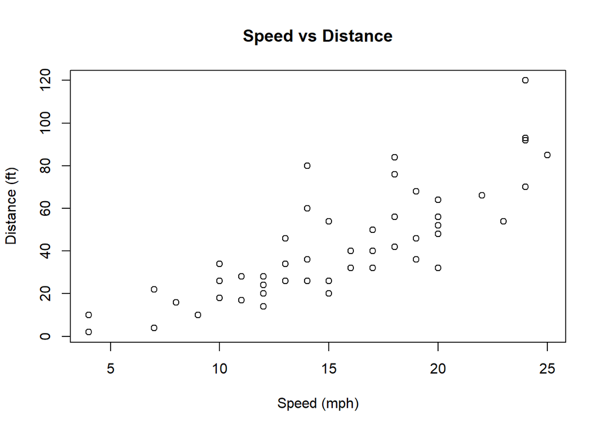

```r
plot(cars$speed,cars$dist, main = "Speed vs Distance", xlab = "Speed (mph)", ylab = "Distance (ft)")
```